# Scup

Abigail Tyrell

04 Jan 2021

This is a preliminary report of previously collected data. This report is pulling information on all Northeast Scup stocks.

## Methods

### General methods

Northeast stocks were identified from NOAA/EDAB ECSA [seasonal species strata](https://github.com/NOAA-EDAB/ECSA/blob/master/data/seasonal_stock_strata.csv).

Data sources for each analysis are identified in the Results.

All continuous temporal data were plotted against time. If there were 30 or more years of data, a geom_gls regression line was fit (yellow = significant increase; purple = significant decrease; no line = no significant trend). If there were fewer than 30 years of data, no regression was fit.

### `assessmentdata` methods

Stock assessment and data quality information were compiled into a summary table.

B/Bmsy was classified as “DANGER” if it was below 1 and “GOOD” if it was above 1.

F/Fmsy was classified as “DANGER” if it was above 1 and “GOOD” if it was below 1.

### `survdat` methods

`survdat` data with zero abundance were not included in this analysis. Abundance and biomass were summed for each year and season. All other metrics were averaged for each year and season. The tables show summary statistics for the entire time series and for the most recent 5 years in the time series.

## Results

### Indicator time series

#### Latitude and longitude

Strata maps were pulled and compiled using code from [NOAA/EDAB ECSA](https://github.com/NOAA-EDAB/ECSA). Please note, only fall and spring strata are shown on the map.

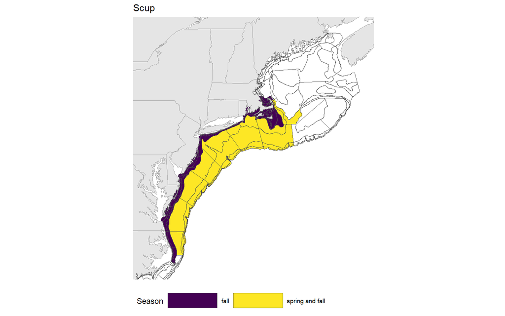

Latitude and longitude ranges were calculated from NOAA/EDAB ECSA [seasonal species strata](https://github.com/NOAA-EDAB/ECSA/blob/master/data/seasonal_stock_strata.csv) and [Bottom Trawl Survey (BTS) shapefiles](https://github.com/NOAA-EDAB/ECSA/tree/master/data/strata_shapefiles). The coordinate system is WGS84.

[output not shown]

#### Stock assessment and data quality information

Stock assessment and data quality information were pulled from `assessmentdata::stockAssessmentSummary`.

| Species | Region | Assessment Year | Last Data Year | Biological Data Rating (2019) | Biological Data Rating (before 2019) | Size Data Rating | Ecosystem Linkage Data Rating | FSSI status | Review Result |
| --- | --- | --- | --- | --- | --- | --- | --- | --- | --- |
| Scup | Atlantic Coast | 2005 | 2005 |  | 0 |  |  | Y | Full acceptance |
| Scup | Atlantic Coast | 2009 | 2007 |  | 2 |  |  | Y | Full acceptance |
| Scup | Atlantic Coast | 2009 | 2008 |  | 2 |  |  | Y | Full acceptance |
| Scup | Atlantic Coast | 2010 | 2009 |  | 2 |  |  | Y | Accept previous approach, remand new attempt |
| Scup | Atlantic Coast | 2011 | 2010 |  | 2 |  |  | Y | Accept previous approach, remand new attempt |
| Scup | Atlantic Coast | 2012 | 2011 |  | 2 |  |  | Y | Accept previous approach, remand new attempt |
| Scup | Atlantic Coast | 2015 | 2014 |  | 2 |  |  | Y | Full acceptance |
| Scup | Atlantic Coast | 2017 | 2016 |  | 2 |  |  | Y | Full acceptance |
| Scup | Atlantic Coast | 2019 | 2018 |  |  | 4 | 1 | Y | Full acceptance |

#### B/Bmsy

B/Bmsy data were pulled from `assessmentdata::stockAssessmentSummary`.

The most recent status of B/Bmsy is: GOOD

##### Figure

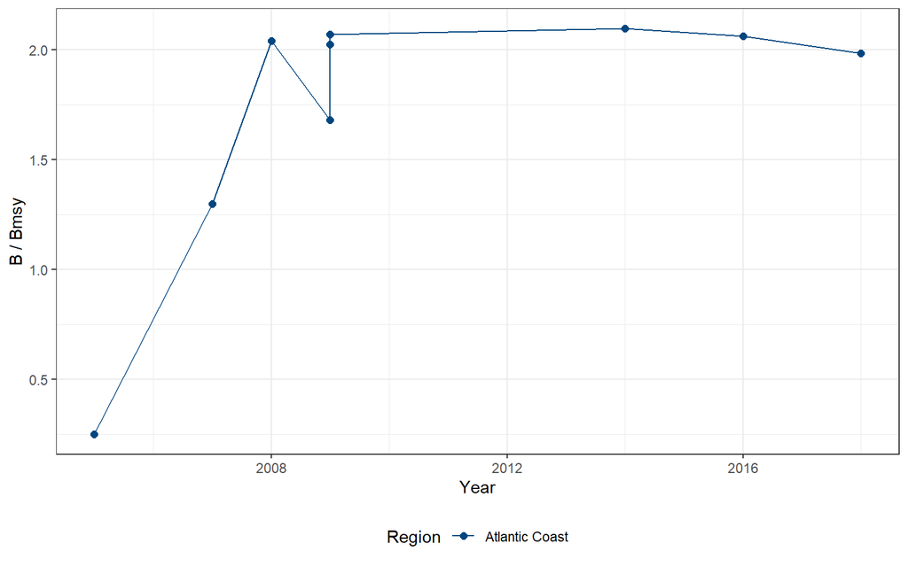

##### Data

| Region | Year | B/Bmsy |
| --- | --- | --- |
| Atlantic Coast | 2005 | 0.25 |
| Atlantic Coast | 2007 | 1.3 |
| Atlantic Coast | 2008 | 2.04 |
| Atlantic Coast | 2009 | 1.68 |
| Atlantic Coast | 2009 | 2.02 |
| Atlantic Coast | 2009 | 2.07 |
| Atlantic Coast | 2014 | 2.1 |
| Atlantic Coast | 2016 | 2.06 |
| Atlantic Coast | 2018 | 1.98 |

#### F/Fmsy

F/Fmsy data were pulled from `assessmentdata::stockAssessmentSummary`.

The most recent status of F/Fmsy is: GOOD

##### Figure

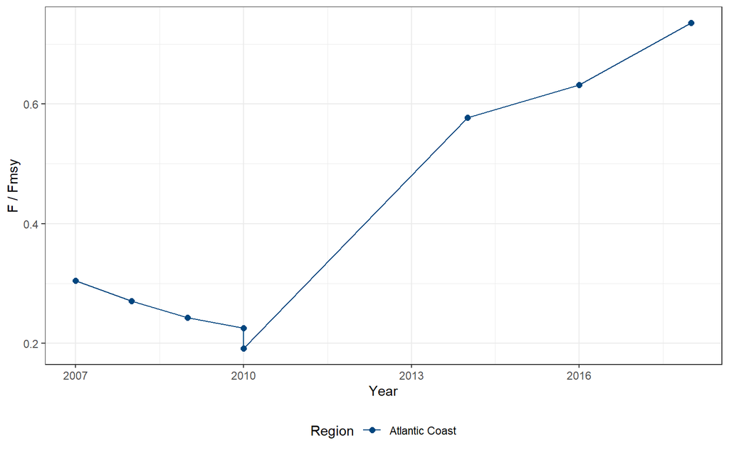

##### Data

| Region | Year | F/Fmsy |
| --- | --- | --- |
| Atlantic Coast | 2007 | 0.31 |
| Atlantic Coast | 2008 | 0.27 |
| Atlantic Coast | 2009 | 0.24 |
| Atlantic Coast | 2010 | 0.23 |
| Atlantic Coast | 2010 | 0.19 |
| Atlantic Coast | 2014 | 0.58 |
| Atlantic Coast | 2016 | 0.63 |
| Atlantic Coast | 2018 | 0.74 |

#### Revenue

Commercial catch data were downloaded from [NOAA FOSS](https://foss.nmfs.noaa.gov/apexfoss/f?p=215:200:4615327020711::NO:::).

##### Figure

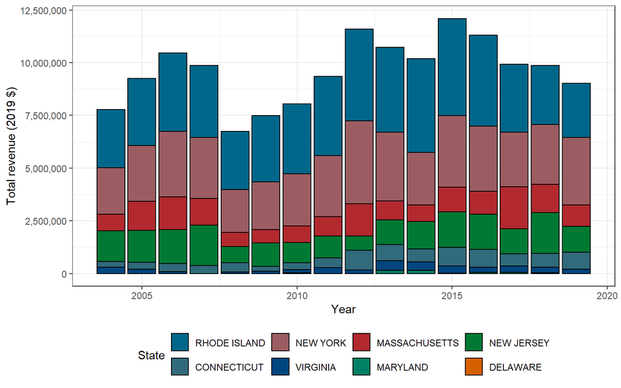

##### Data

| Year | State | Revenue (2019 dollars) | Commercial catch (lb) |
| --- | --- | --- | --- |
| 2019 | Connecticut | 806,582 | 1,141,067 |
| 2019 | Massachusetts | 1,017,368 | 1,247,961 |
| 2019 | New Jersey | 1,230,179 | 1,836,807 |
| 2019 | New York | 3,199,525 | 4,067,582 |
| 2019 | Rhode Island | 2,570,825 | 4,583,835 |
| 2019 | Virginia | 202,962 | 462,085 |
| 2018 | Connecticut | 642,698 | 792,737 |
| 2018 | Maryland | 30,383 | 42,808 |
| 2018 | Massachusetts | 1,323,279 | 1,486,676 |
| 2018 | New Jersey | 1,952,913 | 2,475,986 |

[output cut: 94 more lines]

#### Recruitment

Recruitment data were pulled from `assessmentdata::stockAssessmentData`. Separate geom_gls() functions were fit for each region; trend lines are only shown when the trend was statistically significant, so some plots may have fewer trend lines than regions.

##### Figure

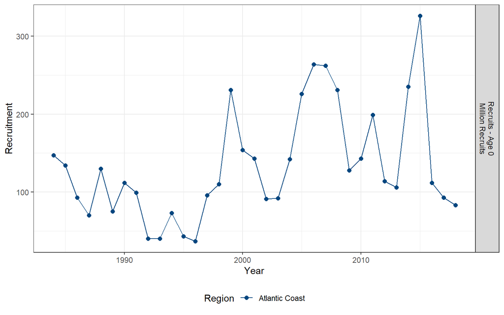

##### Data

| Region | Year | Value | Description | Units |
| --- | --- | --- | --- | --- |
| Atlantic Coast | 1984 | 147 | Recruits - Age 0 | Million Recruits |
| Atlantic Coast | 1985 | 134 | Recruits - Age 0 | Million Recruits |
| Atlantic Coast | 1986 | 93 | Recruits - Age 0 | Million Recruits |
| Atlantic Coast | 1987 | 70 | Recruits - Age 0 | Million Recruits |
| Atlantic Coast | 1988 | 130 | Recruits - Age 0 | Million Recruits |
| Atlantic Coast | 1989 | 75 | Recruits - Age 0 | Million Recruits |
| Atlantic Coast | 1990 | 112 | Recruits - Age 0 | Million Recruits |
| Atlantic Coast | 1991 | 99 | Recruits - Age 0 | Million Recruits |
| Atlantic Coast | 1992 | 40 | Recruits - Age 0 | Million Recruits |
| Atlantic Coast | 1993 | 40 | Recruits - Age 0 | Million Recruits |

[output cut: 25 more lines]

#### Diet

Diet data were compiled from [existing data](https://github.com/Laurels1/Condition/blob/master/data/allfh.RData). For analysis, all geographic samples were grouped by season, year, and region, and only year-season-region combinations with more than 20 predators sampled were considered. Prey items that made up more than 5% of the predator’s diet in at least one year-season-region were identified to the broad category level; all other prey are grouped into the “other” category.

##### Figure

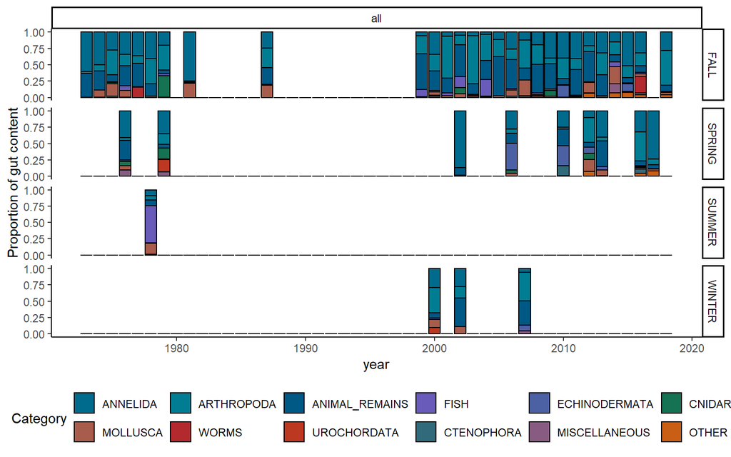

##### Summary

| Prey category | Season | Region | Mean proportion +- SD (n years) | Range |
| --- | --- | --- | --- | --- |
| ANIMAL_REMAINS | FALL | all | 0.273 +- 0.159 (28) | 0.012 - 0.594 |
| ANIMAL_REMAINS | SPRING | all | 0.164 +- 0.123 (9) | 0.058 - 0.395 |
| ANIMAL_REMAINS | SUMMER | all | 0.084 +- NA (1) | 0.084 - 0.084 |
| ANIMAL_REMAINS | WINTER | all | 0.295 +- 0.19 (3) | 0.078 - 0.434 |
| ANNELIDA | FALL | all | 0.284 +- 0.177 (28) | 0.032 - 0.749 |
| ANNELIDA | SPRING | all | 0.412 +- 0.241 (9) | 0.102 - 0.868 |
| ANNELIDA | SUMMER | all | 0.09 +- NA (1) | 0.09 - 0.09 |
| ANNELIDA | WINTER | all | 0.207 +- 0.129 (3) | 0.059 - 0.288 |
| ARTHROPODA | FALL | all | 0.271 +- 0.175 (28) | 0.007 - 0.738 |
| ARTHROPODA | SPRING | all | 0.158 +- 0.162 (8) | 0.029 - 0.442 |
| ARTHROPODA | SUMMER | all | 0.07 +- NA (1) | 0.07 - 0.07 |
| ARTHROPODA | WINTER | all | 0.334 +- 0.139 (3) | 0.176 - 0.436 |
| CNIDARIA | FALL | all | 0.057 +- 0.102 (10) | 0 - 0.328 |
| CNIDARIA | SPRING | all | 0.093 +- 0.052 (4) | 0.047 - 0.167 |
| CTENOPHORA | FALL | all | 0.008 +- NA (1) | 0.008 - 0.008 |
| CTENOPHORA | SPRING | all | 0.111 +- 0.062 (2) | 0.067 - 0.155 |
| ECHINODERMATA | FALL | all | 0.028 +- 0.055 (13) | 0 - 0.179 |
| ECHINODERMATA | SPRING | all | 0.116 +- 0.153 (8) | 0.008 - 0.409 |
| ECHINODERMATA | SUMMER | all | 0.001 +- NA (1) | 0.001 - 0.001 |
| ECHINODERMATA | WINTER | all | 0.056 +- 0.045 (2) | 0.024 - 0.088 |
| FISH | FALL | all | 0.04 +- 0.062 (23) | 0 - 0.257 |
| FISH | SPRING | all | 0.013 +- NA (1) | 0.013 - 0.013 |
| FISH | SUMMER | all | 0.572 +- NA (1) | 0.572 - 0.572 |
| MISCELLANEOUS | FALL | all | 0.019 +- 0.037 (13) | 0 - 0.137 |
| MISCELLANEOUS | SPRING | all | 0.042 +- 0.047 (4) | 0 - 0.096 |
| MISCELLANEOUS | SUMMER | all | 0.011 +- NA (1) | 0.011 - 0.011 |
| MISCELLANEOUS | WINTER | all | 0.044 +- NA (1) | 0.044 - 0.044 |
| MOLLUSCA | FALL | all | 0.077 +- 0.084 (25) | 0.002 - 0.267 |
| MOLLUSCA | SPRING | all | 0.055 +- 0.059 (8) | 0.002 - 0.183 |
| MOLLUSCA | SUMMER | all | 0.171 +- NA (1) | 0.171 - 0.171 |
| MOLLUSCA | WINTER | all | 0.12 +- 0.008 (2) | 0.114 - 0.125 |
| OTHER | FALL | all | 0.027 +- 0.027 (14) | 0 - 0.076 |
| OTHER | SPRING | all | 0.042 +- 0.036 (5) | 0.002 - 0.08 |
| UROCHORDATA | FALL | all | 0 +- NA (1) | 0 - 0 |
| UROCHORDATA | SPRING | all | 0.093 +- 0.131 (2) | 0.001 - 0.186 |
| UROCHORDATA | SUMMER | all | 0.002 +- NA (1) | 0.002 - 0.002 |
| UROCHORDATA | WINTER | all | 0.094 +- NA (1) | 0.094 - 0.094 |
| WORMS | FALL | all | 0.053 +- 0.094 (8) | 0.002 - 0.245 |

##### Data

| Year | Season | Region | Number of fish | Prey category | Prey weight | Prey proportion |
| --- | --- | --- | --- | --- | --- | --- |
| 1973 | FALL | all | 27 | Animal remains | 11.46 | 0.363 |
| 1973 | FALL | all | 27 | Annelida | 18.96 | 0.601 |
| 1973 | FALL | all | 27 | Arthropoda | 0.99 | 0.031 |
| 1973 | FALL | all | 27 | Miscellaneous | 0.15 | 0.005 |
| 1974 | FALL | all | 62 | Animal remains | 12.1 | 0.291 |
| 1974 | FALL | all | 62 | Annelida | 20.71 | 0.498 |
| 1974 | FALL | all | 62 | Arthropoda | 3.87 | 0.093 |
| 1974 | FALL | all | 62 | Chaetognatha | 0.02 | 0 |
| 1974 | FALL | all | 62 | Fish | 0.27 | 0.006 |
| 1974 | FALL | all | 62 | Miscellaneous | 0.09 | 0.002 |

[output cut: 269 more lines]

#### Temperature

Surface and bottom temperature data were pulled from `survdat`.

##### Figures

Separate geom_gls() functions were fit for fall and spring measurements; trend lines are only shown when the trend was statistically significant, so some plots may have fewer than two trend lines. Fall has solid trend lines, and spring has dashed trend lines. Please note, sometimes the survey observed a small number of fish outside of the defined stock area.

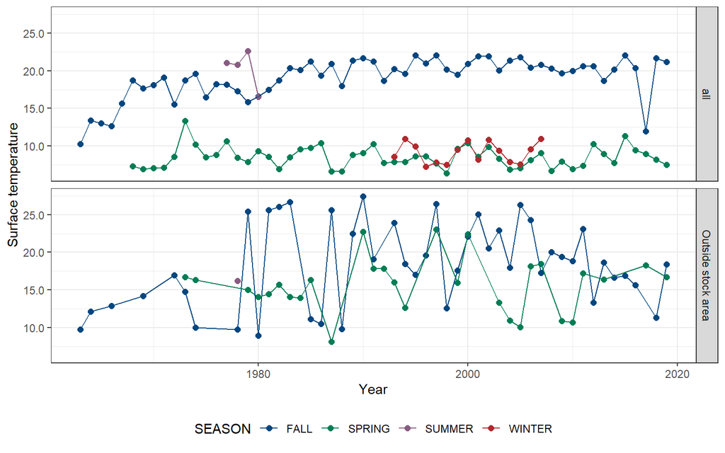

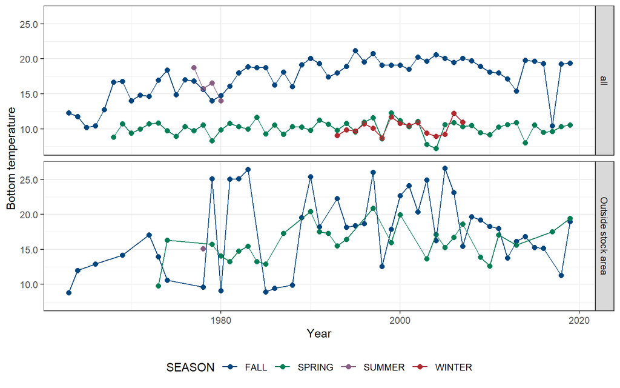

##### Summary

Surface temperature

| Season | Region | Mean value +- SD (n years) | Mean value +- SD (past 5 years) | Range (total) | Range (past 5 years) |
| --- | --- | --- | --- | --- | --- |
| FALL | all | 19.04 +- 2.74 (57) | 19.43 +- 4.25 (5) | 10.23 - 22.04 | 11.92 - 22.03 |
| FALL | Outside stock area | 18.33 +- 5.61 (46) | 15.54 +- 3.05 (4) | 8.9 - 27.46 | 11.29 - 18.37 |
| SPRING | all | 8.51 +- 1.39 (52) | 9.07 +- 1.46 (5) | 6.33 - 13.31 | 7.47 - 11.33 |
| SPRING | Outside stock area | 15.65 +- 3.63 (29) | 17.47 +- 1.09 (2) | 8.1 - 23.03 | 16.69 - 18.24 |
| SUMMER | all | 20.24 +- 2.63 (4) | 20.24 +- 2.63 (4) | 16.5 - 22.64 | 16.5 - 22.64 |
| SUMMER | Outside stock area | 16.2 +- NA (1) | 16.2 +- NA (1) | 16.2 - 16.2 | 16.2 - 16.2 |
| WINTER | all | 9.1 +- 1.37 (15) | 9.06 +- 1.36 (5) | 7.22 - 10.94 | 7.57 - 10.91 |

Bottom temperature

| Season | Region | Mean value +- SD (n years) | Mean value +- SD (past 5 years) | Range (total) | Range (past 5 years) |
| --- | --- | --- | --- | --- | --- |
| FALL | all | 17.36 +- 2.77 (57) | 17.63 +- 4.01 (5) | 10.22 - 21.17 | 10.45 - 19.66 |
| FALL | Outside stock area | 17.58 +- 5.43 (45) | 15.18 +- 3.13 (4) | 8.8 - 26.61 | 11.29 - 18.95 |
| SPRING | all | 10.09 +- 0.99 (52) | 10.12 +- 0.5 (5) | 7.19 - 12.28 | 9.53 - 10.56 |
| SPRING | Outside stock area | 16.01 +- 2.53 (29) | 18.49 +- 1.33 (2) | 9.8 - 20.88 | 17.56 - 19.43 |
| SUMMER | all | 16.28 +- 1.96 (4) | 16.28 +- 1.96 (4) | 14.05 - 18.77 | 14.05 - 18.77 |
| SUMMER | Outside stock area | 15.1 +- NA (1) | 15.1 +- NA (1) | 15.1 - 15.1 | 15.1 - 15.1 |
| WINTER | all | 10.19 +- 1.04 (15) | 10.16 +- 1.41 (5) | 8.74 - 12.26 | 8.94 - 12.26 |

##### Data

| Year | Season | Region | Mean surface temperature | Mean bottom temperature |
| --- | --- | --- | --- | --- |
| 1963 | FALL | all | 10.23 | 12.32 |
| 1963 | FALL | Outside stock area | 9.7 | 8.8 |
| 1964 | FALL | all | 13.38 | 11.76 |
| 1964 | FALL | Outside stock area | 12.1 | 12 |
| 1965 | FALL | all | 13 | 10.22 |
| 1966 | FALL | all | 12.63 | 10.43 |
| 1966 | FALL | Outside stock area | 12.9 | 12.9 |
| 1967 | FALL | all | 15.65 |  |
| 1968 | FALL | all | 18.75 |  |
| 1968 | SPRING | all | 7.29 |  |

[output cut: 194 more lines]

#### Salinity

Surface and bottom salinity data were pulled from `survdat`.

##### Figures

Separate geom_gls() functions were fit for fall and spring measurements; trend lines are only shown when the trend was statistically significant, so some plots may have fewer than two trend lines. Fall has solid trend lines, and spring has dashed trend lines. Please note, sometimes the survey observed a small number of fish outside of the defined stock area.

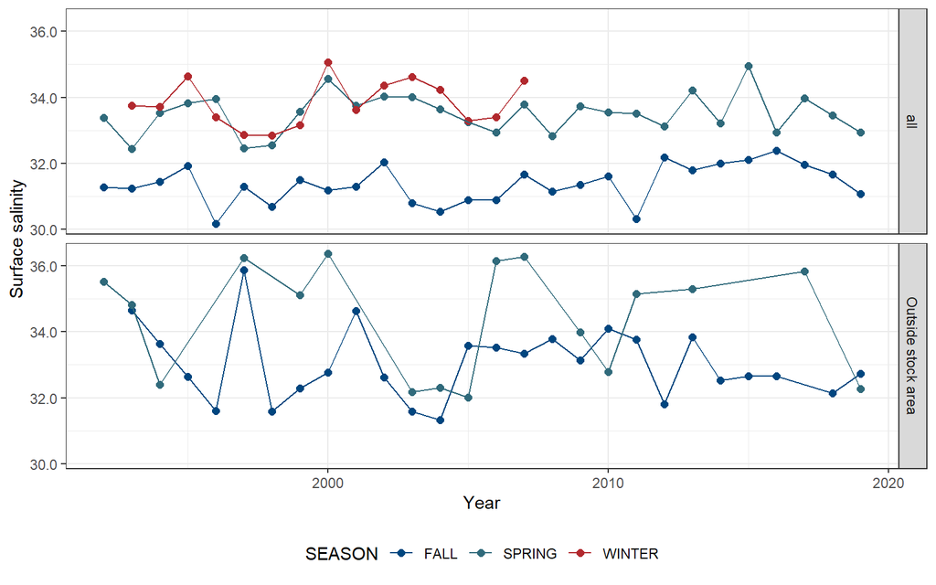

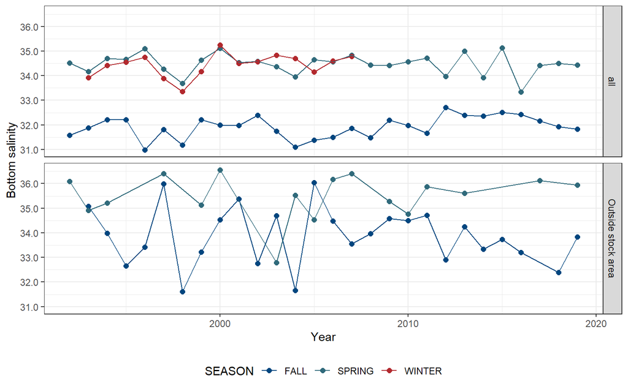

##### Summary

Surface salinity

| Season | Region | Mean value +- SD (n years) | Mean value +- SD (past 5 years) | Range (total) | Range (past 5 years) |
| --- | --- | --- | --- | --- | --- |
| FALL | all | 31.38 +- 0.57 (28) | 31.84 +- 0.5 (5) | 30.17 - 32.39 | 31.08 - 32.39 |
| FALL | Outside stock area | 33.03 +- 1.1 (26) | 32.54 +- 0.28 (4) | 31.34 - 35.86 | 32.13 - 32.73 |
| SPRING | all | 33.51 +- 0.61 (28) | 33.65 +- 0.85 (5) | 32.44 - 34.96 | 32.94 - 34.96 |
| SPRING | Outside stock area | 34.39 +- 1.69 (17) | 34.05 +- 2.51 (2) | 32.01 - 36.37 | 32.28 - 35.83 |
| WINTER | all | 33.83 +- 0.69 (15) | 34.01 +- 0.62 (5) | 32.84 - 35.07 | 33.3 - 34.63 |

Bottom salinity

| Season | Region | Mean value +- SD (n years) | Mean value +- SD (past 5 years) | Range (total) | Range (past 5 years) |
| --- | --- | --- | --- | --- | --- |
| FALL | all | 31.92 +- 0.44 (28) | 32.17 +- 0.3 (5) | 30.98 - 32.71 | 31.82 - 32.5 |
| FALL | Outside stock area | 33.86 +- 1.16 (26) | 33.29 +- 0.66 (4) | 31.61 - 36.04 | 32.4 - 33.83 |
| SPRING | all | 34.47 +- 0.42 (28) | 34.37 +- 0.65 (5) | 33.33 - 35.13 | 33.33 - 35.13 |
| SPRING | Outside stock area | 35.49 +- 0.93 (17) | 36.03 +- 0.14 (2) | 32.79 - 36.56 | 35.93 - 36.13 |
| WINTER | all | 34.43 +- 0.47 (15) | 34.61 +- 0.27 (5) | 33.35 - 35.25 | 34.15 - 34.84 |

##### Data

| Year | Season | Region | Mean surface salinity | Mean bottom salinity |
| --- | --- | --- | --- | --- |
| 1992 | FALL | all | 31.29 |  |
| 1992 | SPRING | all | 33.38 | 34.52 |
| 1992 | SPRING | Outside stock area | 35.52 | 36.09 |
| 1993 | FALL | all | 31.24 | 31.88 |
| 1993 | FALL | Outside stock area | 34.65 | 35.08 |
| 1993 | SPRING | all | 32.44 | 34.18 |
| 1993 | SPRING | Outside stock area | 34.81 | 34.92 |
| 1993 | WINTER | all | 33.75 | 33.92 |
| 1994 | FALL | all | 31.44 | 32.21 |
| 1994 | FALL | Outside stock area | 33.64 | 33.97 |

[output cut: 104 more lines]

#### Abundance

Abundance data were pulled from `survdat` and `assessmentdata::stockAssessmentData`.

##### Figures

Separate geom_gls() functions were fit for fall and spring measurements; trend lines are only shown when the trend was statistically significant, so some plots may have fewer than two trend lines. Fall has solid trend lines, and spring has dashed trend lines. Please note, sometimes the survey observed a small number of fish outside of the defined stock area.

Survey abundance (raw measurements):

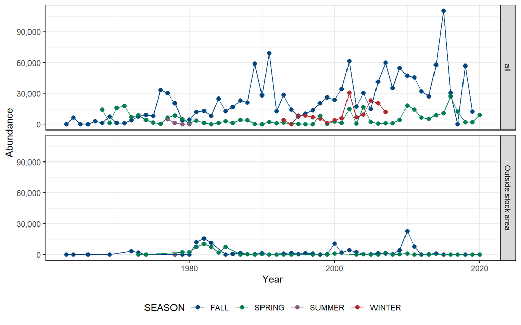

Survey abundance (swept area estimates):

Please note, these estimates are not parsed by region or season. Swept area estimates are based on spring and fall surveys only. The shaded gray region indicates +/- two standard errors.

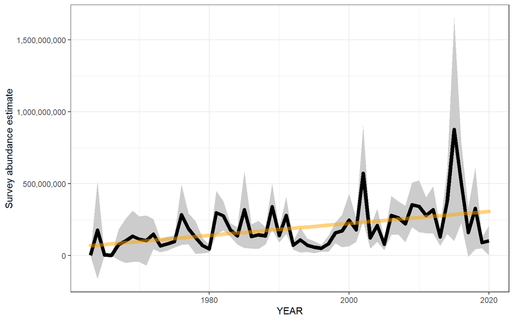

Assessment abundance:

```
## [1] "NO DATA"
```

##### Survey summary

Measured abundance

| Season | Region | Mean value +- SD (n years) | Mean value +- SD (past 5 years) | Range (total) | Range (past 5 years) |
| --- | --- | --- | --- | --- | --- |
| FALL | all | 23,941.12 +- 21,916.15 (57) | 42,115.2 +- 43,762.25 (5) | 3 - 110,481 | 3 - 110,481 |
| FALL | Outside stock area | 2,447.06 +- 4,738.93 (47) | 42.8 +- 34.47 (5) | 1 - 22,977 | 1 - 83 |
| SPRING | all | 5,576.58 +- 6,182.51 (53) | 10,692.2 +- 10,337.7 (5) | 113 - 27,328 | 2,134 - 27,328 |
| SPRING | Outside stock area | 1,335.24 +- 2,668.38 (34) | 23.75 +- 18.73 (4) | 1 - 10,453 | 5 - 46 |
| SUMMER | all | 1,608.5 +- 2,336.45 (4) | 1,608.5 +- 2,336.45 (4) | 4 - 5,001 | 4 - 5,001 |
| SUMMER | Outside stock area | 1 +- NA (1) | 1 +- NA (1) | 1 - 1 | 1 - 1 |
| WINTER | all | 9,999.93 +- 8,569.94 (15) | 14,689.6 +- 7,151.34 (5) | 105 - 30,655 | 7,181 - 23,599 |

##### Data

Survey data (raw measurements):

| Year | Season | Region | Abundance |
| --- | --- | --- | --- |
| 1963 | FALL | all | 90 |
| 1963 | FALL | Outside stock area | 3 |
| 1964 | FALL | all | 6,601 |
| 1964 | FALL | Outside stock area | 15 |
| 1965 | FALL | all | 122 |
| 1966 | FALL | all | 68 |
| 1966 | FALL | Outside stock area | 2 |
| 1967 | FALL | all | 3,221 |
| 1968 | FALL | all | 1,543 |
| 1968 | SPRING | all | 14,415 |

[output cut: 201 more lines]

Survey data (swept area estimates):

| Year | Abundance | Standard error |
| --- | --- | --- |
| 1963 | 3,371,697 | 1,575,961.7 |
| 1964 | 177,062,163 | 169,811,753.3 |
| 1965 | 5,776,944 | 2,638,965.8 |
| 1966 | 3,088,652 | 933,098.8 |
| 1967 | 76,661,433 | 52,910,409.0 |
| 1968 | 103,239,398 | 76,373,516.6 |
| 1969 | 135,230,604 | 88,808,868.4 |
| 1970 | 114,738,287 | 79,225,010.4 |
| 1971 | 106,132,886 | 87,234,987.4 |
| 1972 | 150,316,371 | 52,386,096.7 |

[output cut: 48 more lines]

Assessment data:

| Region | Year | Value | Description | Units |
| --- | --- | --- | --- | --- |

#### Biomass

Biomass data were pulled from `survdat`.

##### Figures

Separate geom_gls() functions were fit for fall and spring measurements; trend lines are only shown when the trend was statistically significant, so some plots may have fewer than two trend lines. Fall has solid trend lines, and spring has dashed trend lines. Please note, sometimes the survey observed a small number of fish outside of the defined stock area.

Survey biomass (raw measurements):

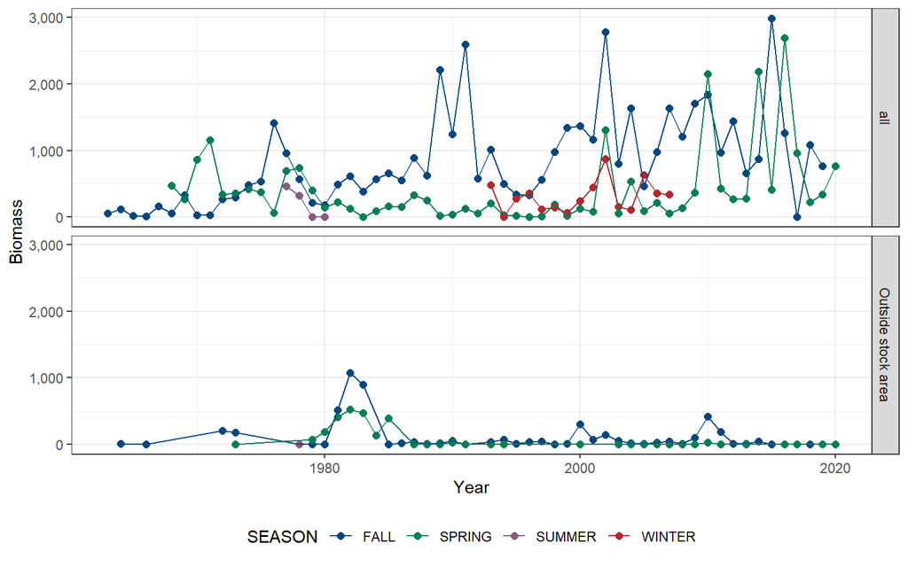

Survey biomass (swept area estimates):

Please note, these estimates are not parsed by region or season. Swept area estimates are based on spring and fall surveys only. The shaded gray region indicates +/- two standard errors.

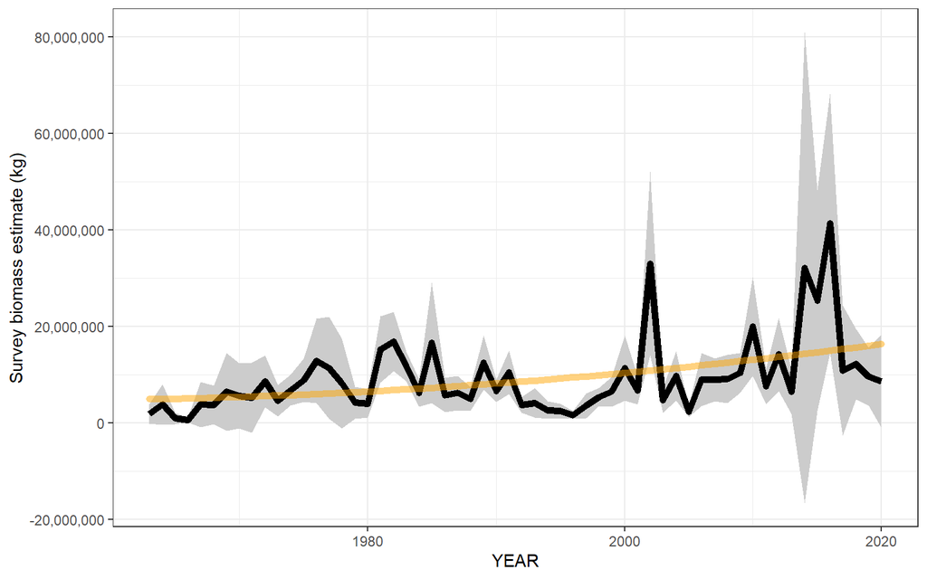

Assessment biomass:

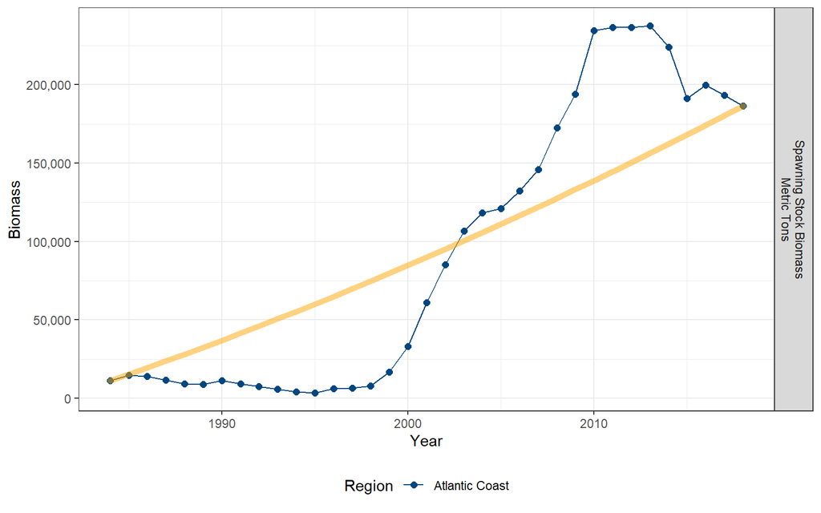

##### Summary

Measured biomass

| Season | Region | Mean value +- SD (n years) | Mean value +- SD (past 5 years) | Range (total) | Range (past 5 years) |
| --- | --- | --- | --- | --- | --- |
| FALL | all | 840.05 +- 700.36 (57) | 1,221.31 +- 1,099.22 (5) | 0.55 - 2,986.27 | 0.55 - 2,986.27 |
| FALL | Outside stock area | 106.79 +- 224.32 (44) | 1.94 +- 1.67 (5) | 0.05 - 1,078.9 | 0.05 - 4.5 |
| SPRING | all | 417.37 +- 562.61 (53) | 997.63 +- 996.16 (5) | 3.9 - 2,696.61 | 225.65 - 2,696.61 |
| SPRING | Outside stock area | 75.85 +- 156.59 (30) | 0.95 +- 0.87 (4) | 0.03 - 527.2 | 0.19 - 1.87 |
| SUMMER | all | 200.43 +- 234.32 (4) | 200.43 +- 234.32 (4) | 0.7 - 468.6 | 0.7 - 468.6 |
| SUMMER | Outside stock area | 0.4 +- NA (1) | 0.4 +- NA (1) | 0.4 - 0.4 | 0.4 - 0.4 |
| WINTER | all | 307.81 +- 233.54 (15) | 320.9 +- 208.57 (5) | 3.5 - 868.89 | 110.89 - 635.37 |

##### Data

Survey data (raw measurements):

[output not shown]

[output cut: 201 more lines]

Survey data (swept area estimates):

| Year | Biomass (kg) | Standard error |
| --- | --- | --- |
| 1963 | 1,911,226.7 | 981,559.9 |
| 1964 | 3,831,047.0 | 2,081,032.3 |
| 1965 | 996,719.7 | 590,606.9 |
| 1966 | 642,768.3 | 271,135.6 |
| 1967 | 3,854,833.7 | 2,342,371.4 |
| 1968 | 3,745,468.0 | 2,014,241.5 |
| 1969 | 6,463,982.7 | 4,015,149.9 |
| 1970 | 5,584,471.4 | 3,371,971.7 |
| 1971 | 5,269,452.1 | 3,629,580.1 |
| 1972 | 8,607,340.5 | 2,682,655.4 |

[output cut: 48 more lines]

Assessment data:

| Region | Year | Value | Description | Units |
| --- | --- | --- | --- | --- |
| Atlantic Coast | 1984 | 11,091 | Spawning Stock Biomass | Metric Tons |
| Atlantic Coast | 1985 | 14,688 | Spawning Stock Biomass | Metric Tons |
| Atlantic Coast | 1986 | 13,928 | Spawning Stock Biomass | Metric Tons |
| Atlantic Coast | 1987 | 11,667 | Spawning Stock Biomass | Metric Tons |
| Atlantic Coast | 1988 | 9,353 | Spawning Stock Biomass | Metric Tons |
| Atlantic Coast | 1989 | 8,809 | Spawning Stock Biomass | Metric Tons |
| Atlantic Coast | 1990 | 11,291 | Spawning Stock Biomass | Metric Tons |
| Atlantic Coast | 1991 | 9,290 | Spawning Stock Biomass | Metric Tons |
| Atlantic Coast | 1992 | 7,518 | Spawning Stock Biomass | Metric Tons |
| Atlantic Coast | 1993 | 5,713 | Spawning Stock Biomass | Metric Tons |

[output cut: 25 more lines]

#### Catch

Stock assessment catch data are from `assessmentdata::stockAssessmentData`. Recreational catch data were downloaded from [NOAA MRIP](https://www.st.nmfs.noaa.gov/st1/recreational/MRIP_Estimate_Data/CSV/). Commercial catch data were downloaded from [NOAA FOSS](https://foss.nmfs.noaa.gov/apexfoss/f?p=215:200:4615327020711::NO:::).

##### Figures

Stock assessment catch:

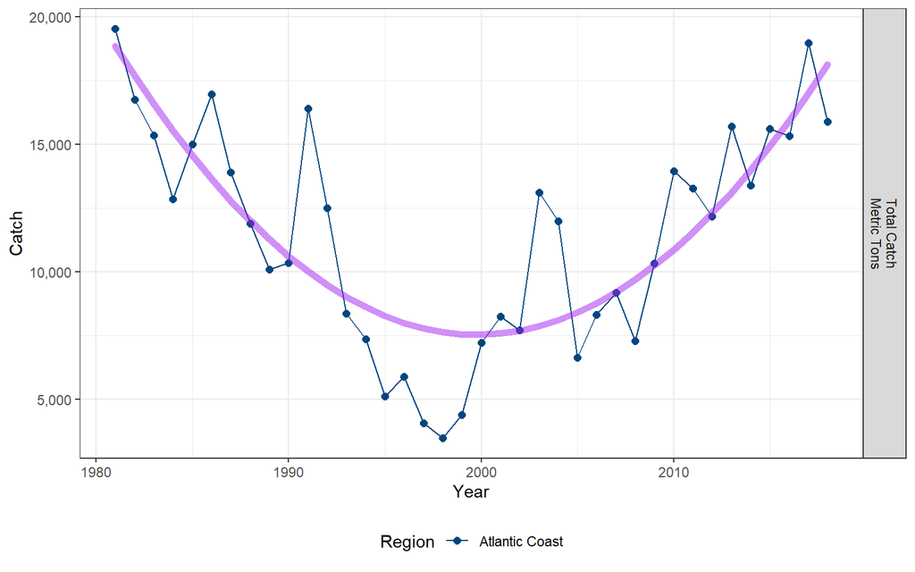

Recreational catch:

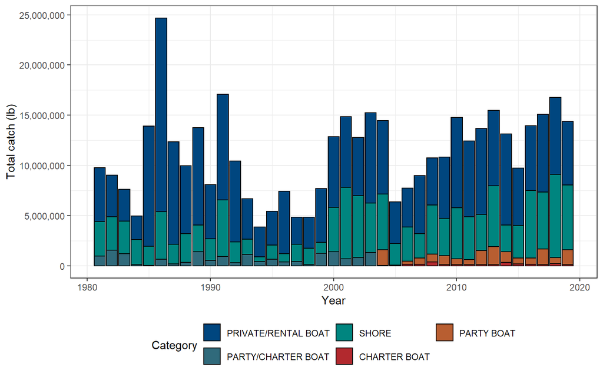

Commercial catch:

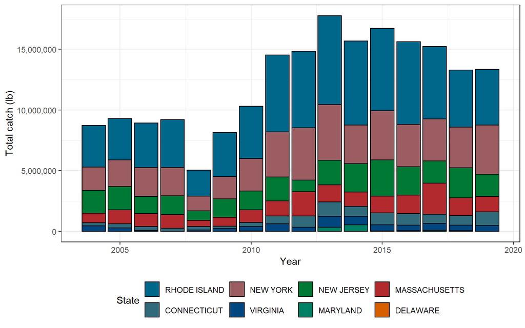

Commercial vs recreational catch:

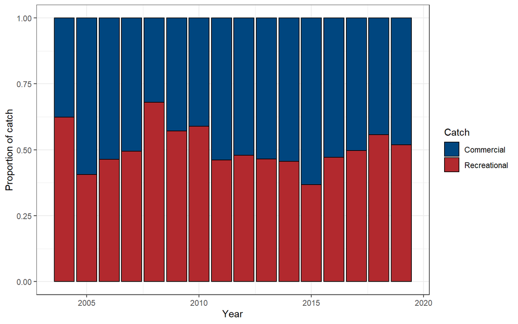

##### Data

Stock assessment catch:

| Region | Year | Value | Description | Units |
| --- | --- | --- | --- | --- |
| Atlantic Coast | 1981 | 19,514 | Total Catch | Metric Tons |
| Atlantic Coast | 1982 | 16,751 | Total Catch | Metric Tons |
| Atlantic Coast | 1983 | 15,336 | Total Catch | Metric Tons |
| Atlantic Coast | 1984 | 12,836 | Total Catch | Metric Tons |
| Atlantic Coast | 1985 | 14,989 | Total Catch | Metric Tons |
| Atlantic Coast | 1986 | 16,965 | Total Catch | Metric Tons |
| Atlantic Coast | 1987 | 13,902 | Total Catch | Metric Tons |
| Atlantic Coast | 1988 | 11,882 | Total Catch | Metric Tons |
| Atlantic Coast | 1989 | 10,096 | Total Catch | Metric Tons |
| Atlantic Coast | 1990 | 10,350 | Total Catch | Metric Tons |

[output cut: 28 more lines]

Recreational catch:

| Year | State | Method | Catch (lb) |
| --- | --- | --- | --- |
| 1981 | Connecticut | Shore | 181,881 |
| 1981 | Connecticut | Party/charter boat | 266,075 |
| 1981 | Connecticut | Private/rental boat | 6,067 |
| 1981 | Connecticut | Private/rental boat | 65,195 |
| 1981 | Connecticut | Private/rental boat | 2,441,784 |
| 1981 | Massachusetts | Shore | 422,776 |
| 1981 | Massachusetts | Shore | 1,389,963 |
| 1981 | Massachusetts | Party/charter boat | 509,643 |
| 1981 | Massachusetts | Party/charter boat | 72,531 |
| 1981 | Massachusetts | Party/charter boat | 131,169 |

[output cut: 776 more lines]

Commercial catch:

| Year | State | Revenue (2019 dollars) | Commercial catch (lb) |
| --- | --- | --- | --- |
| 2019 | Connecticut | 806,582 | 1,141,067 |
| 2019 | Massachusetts | 1,017,368 | 1,247,961 |
| 2019 | New Jersey | 1,230,179 | 1,836,807 |
| 2019 | New York | 3,199,525 | 4,067,582 |
| 2019 | Rhode Island | 2,570,825 | 4,583,835 |
| 2019 | Virginia | 202,962 | 462,085 |
| 2018 | Connecticut | 642,698 | 792,737 |
| 2018 | Maryland | 30,383 | 42,808 |
| 2018 | Massachusetts | 1,323,279 | 1,486,676 |
| 2018 | New Jersey | 1,952,913 | 2,475,986 |

[output cut: 94 more lines]

Commercial vs recreational catch:

| Year | Recreational catch | Commercial catch | Total catch | Proportion recreational | Proportion commercial |
| --- | --- | --- | --- | --- | --- |
| 2004 | 14,470,240 | 8,713,000 | 23,183,240 | 0.624 | 0.376 |
| 2005 | 6,354,125 | 9,297,302 | 15,651,427 | 0.406 | 0.594 |
| 2006 | 7,723,858 | 8,917,004 | 16,640,862 | 0.464 | 0.536 |
| 2007 | 8,975,602 | 9,193,359 | 18,168,961 | 0.494 | 0.506 |
| 2008 | 10,742,042 | 5,047,081 | 15,789,123 | 0.68 | 0.32 |
| 2009 | 10,839,976 | 8,131,927 | 18,971,903 | 0.571 | 0.429 |
| 2010 | 14,790,911 | 10,291,579 | 25,082,490 | 0.59 | 0.41 |
| 2011 | 12,422,170 | 14,539,511 | 26,961,681 | 0.461 | 0.539 |
| 2012 | 13,670,208 | 14,846,830 | 28,517,038 | 0.479 | 0.521 |
| 2013 | 15,468,627 | 17,781,471 | 33,250,098 | 0.465 | 0.535 |

[output cut: 6 more lines]

#### Length

Length data were pulled from `survdat`. Only years with more than 10 fish lengths were considered for analysis.

##### Figures

Separate geom_gls() functions were fit for the minimum, mean, and maximum lengths; trend lines are only shown when the trend was statistically significant, so some plots may have fewer than three trend lines. Please note, sometimes the survey observed a small number of fish outside of the defined stock area.

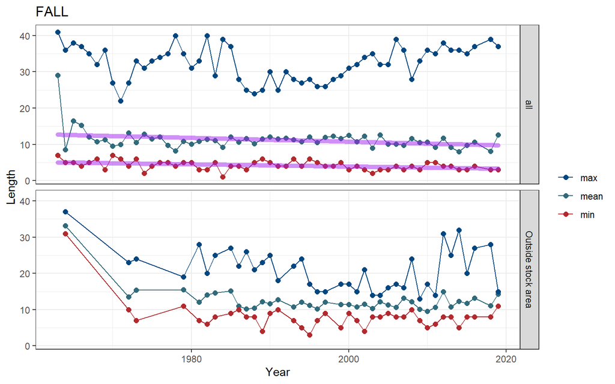

[output not shown]

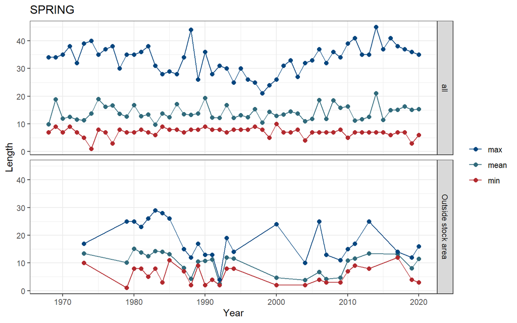

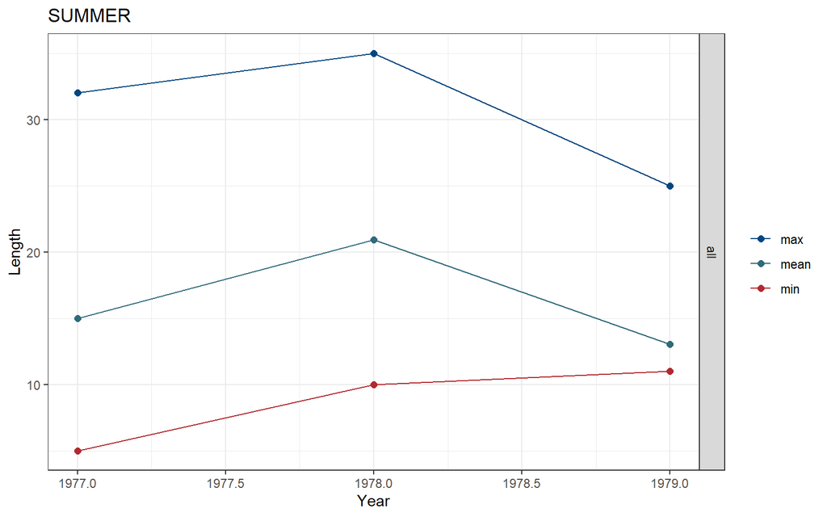

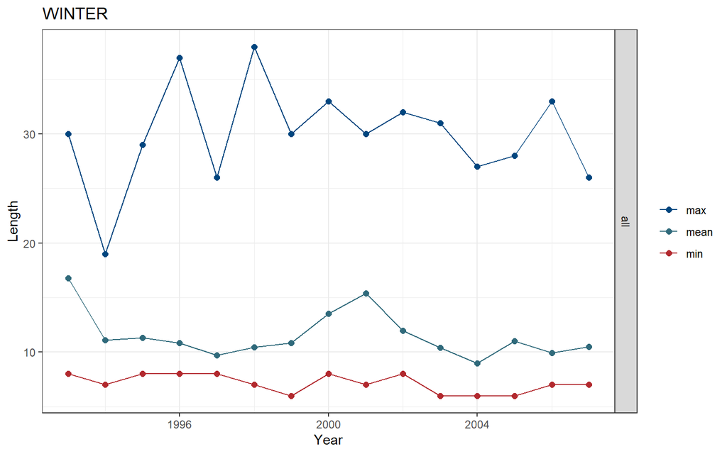

##### Summary

| Season | Region | Mean value +- SD (n fish, n years) | Mean value +- SD (n fish, past 5 years) | Range (total) | Range (past 5 years) |
| --- | --- | --- | --- | --- | --- |
| FALL | all | 10.61 +- 3.32 (1,364,641, 56) | 9.62 +- 3.56 (210,573, 4) | 1 - 41 | 3 - 39 |
| FALL | Outside stock area | 11.8 +- 2.41 (114,989, 39) | 12.29 +- 2.76 (213, 4) | 3 - 37 | 8 - 28 |
| SPRING | all | 13.52 +- 4.69 (295,559, 53) | 15.16 +- 4.65 (53,461, 5) | 1 - 45 | 3 - 41 |
| SPRING | Outside stock area | 12.46 +- 3.38 (45,378, 27) | 11.62 +- 3.6 (90, 3) | 1 - 29 | 3 - 16 |
| SUMMER | all | 16.6 +- 7.26 (4,057, 3) | 16.6 +- 7.26 (4,057, 3) | 5 - 35 | 5 - 35 |
| WINTER | all | 11.01 +- 2.72 (129,420, 15) | 10.29 +- 1.93 (73,123, 5) | 6 - 38 | 6 - 33 |

##### Data

| Year | Season | Region | Number of fish | Mean length | Minimum length | Maximum length |
| --- | --- | --- | --- | --- | --- | --- |
| 1963 | FALL | all | 90 | 29.08 | 7 | 41 |
| 1964 | FALL | all | 6,601 | 8.48 | 5 | 36 |
| 1964 | FALL | Outside stock area | 15 | 33.2 | 31 | 37 |
| 1965 | FALL | all | 122 | 16.5 | 5 | 38 |
| 1966 | FALL | all | 68 | 15.31 | 4 | 37 |
| 1967 | FALL | all | 3,221 | 12.09 | 5 | 35 |
| 1968 | FALL | all | 1,543 | 10.71 | 6 | 32 |
| 1968 | SPRING | all | 14,415 | 9.87 | 7 | 34 |
| 1969 | FALL | all | 7,597 | 11.25 | 3 | 36 |
| 1969 | SPRING | all | 1,530 | 18.87 | 9 | 34 |

[output cut: 183 more lines]

#### Condition

Condition information comes from [diet data](https://github.com/Laurels1/Condition/blob/master/data/allfh.RData); only regions and seasons with more than 10 fish observations were considered. We calculated a rough condition factor as: Weight / Length^3, and relative weight was [previously calculated](https://github.com/Laurels1/Condition/tree/master/data).

##### Figures

Length vs weight

Please note, no trend lines were fit, points are jittered to reduce overlap, and sometimes the survey observed a small number of fish outside of the defined stock area.

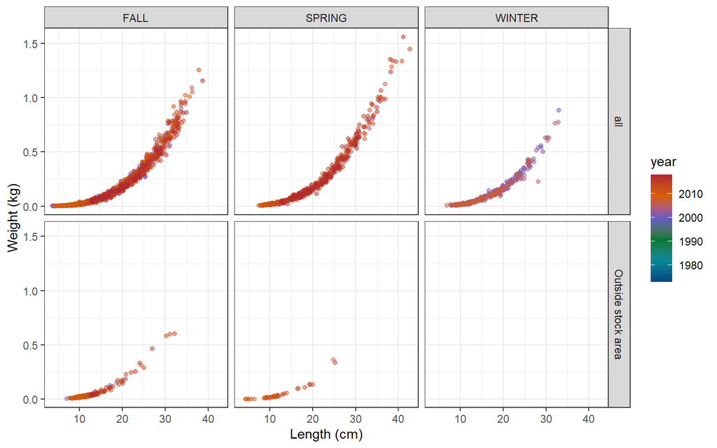

Condition factor: Weight-volume

If there were more than 30 years of data, a geom_gls() regression was fit. In order to fit the geom_gls() regression, we calculated the mean condition factor for each year and plotted the geom_gls() through those points. Please note, points are jittered to reduce overlap, and sometimes the survey observed a small number of fish outside of the defined stock area.

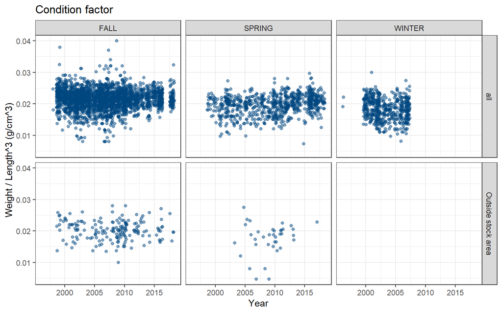

Condition factor: Relative weight

Please note, this data is aggregated by Ecological Protection Unit (EPU), which may differ slightly from the stock assessment regions.

```
## [1] "NO DATA"
```

##### Data

Length vs weight with weight-volume condition factor

[output not shown]

[output cut: 4037 more lines]

Relative weight condition factor Please note, this data is aggregated by Ecological Protection Unit (EPU), which may differ slightly from the stock assessment regions.

| EPU | Fish sex | Year | Mean condition | Number of fish |
| --- | --- | --- | --- | --- |

### Risk analysis

A preliminary risk analysis was conducted by ranking all species according to their indicator values. A high rank number and a normalized rank near 1 indicates that the species is at risk or of importance based on the measured indicator values. When a species was missing an indicator, it was assigned a normalized rank of 0.5.

| Region | Category | Indicator | Year | Value | Rank | Normalized rank |
| --- | --- | --- | --- | --- | --- | --- |
| Atlantic | Biological | bbmsy | 2018 | 1.98 | 6 out of 41 | 0.15 |
| Atlantic | Social | ffmsy | 2018 | 0.74 | 22 out of 36 | 0.61 |
| Atlantic | Social | asmt_catch | 1981 | 19,514.00 | 28 out of 43 | 0.65 |
| Atlantic | Biological | recruitment | mean of last 10 years vs historic mean | 1.25 | 8 out of 20 | 0.4 |
| Atlantic | Biological | abundance | mean of last 10 years vs historic mean | 4.25 | 2 out of 37 | 0.05 |
| Atlantic | Biological | biomass_fall | mean of last 10 years vs historic mean | 1.55 | 27 out of 51 | 0.53 |
| Atlantic | Biological | biomass_spring | mean of last 10 years vs historic mean | 1.53 | 21 out of 51 | 0.41 |
| Atlantic | Biological | avg_length_fall | mean of last 10 years vs historic mean | 0.93 | 27 out of 51 | 0.53 |
| Atlantic | Biological | avg_length_spring | mean of last 10 years vs historic mean | 0.92 | 28 out of 51 | 0.55 |
| Atlantic | Biological | max_length_fall | mean of last 10 years vs historic mean | 1.06 | 8 out of 51 | 0.16 |

[output cut: 9 more lines]